# Assignment: Introduction to People Analytics with R

Dunja Novaković

2021-07-19

## Instructions

This first assignment reviews my *Introduction to Data* analytical lecture. You will use the *data_introduction.Rmd* file I reviewed in the video lectures to complete this assignment. You will *copy and paste* relevant code from that file and update it to answer the questions in this assignment. You will respond to questions in each section after executing relevant code to answer a question. You will submit this assignment to its *Submissions* folder on *D2L*. You will submit:

1. this completed **R Markdown** script, and
2. a *HTML* rendered version of it to *D2L*.

To start:

First, create a folder on your computer to save all relevant files for this assignment. Most likely, you will want to create a folder named *MGT 591* that contains all of the materials for this course.

Second, inside of *MGT 591*, you will create a folder to host assignments. You can name that folder *Assignments*.

Third, inside of *Assignments*, you will create folders for each assignment. The folder for this first assignment you can name *data_introduction*.

Fourth, create three additional folders in *data_introduction* named *scripts*, *data*, and *plots*. Store this script in the *scripts* folder, the data for this assignment in the *data* folder, and any requested plots from this assignment in the *plots* folder.

Fifth, go to the *File* menu in *RStudio*, select *New Project…*, choose *Existing Directory*, go to your *~/MGT 591/Assignments/data_introduction* folder to select it as the top-level directory for this **R Project**.

## Global Settings

The first code chunk sets the global settings for the remaining code chunks in the document. Do *not* change anything in this code chunk.

## Load Packages

In this code chunk, we load three packages we need for this assignment:

1. **here**,
2. **tidyverse**, and
3. **haven**.

We will use functions from these packages to examine the data, calculate summaries, and create visualizations. Do *not* change anything in this code chunk.

```r
### load libaries for use in current working session
## library "here" for workflow
library(here)

## tidyverse for data manipulation and plotting
# loads eight different libraries simultaneously
library(tidyverse)

## haven to import SPSS data
library(haven)
```

## Task 1: Load Data

As your first task for this assignment, you need to load the data of interest for the assignment. We will use the same data as in the analytical lecture: **diversity_ind.sav**. After you load the data, then you will execute other commands on the data.

Use the **read_spss** function from the **haven** package and the **here** function from the **here** package to load the data for this working session. Save the data as the object **div_orig_data**.

**Question 1.1**: After you load the data, look at your *Global Environment* window. How many observations and variables exist in the data?

**Response 1.1**: *1,493 observations and 11 variables*.

**Question 1.2**: Use the **glimpse** function to view a preview of values for each variable in the data. Which variable is listed last?

**Response 1.2**: *leaver*.

```r
#### Q1.1
### import data file
## use here() to locate file in our project directory;
## use read_spss to import the SPSS data file
div_orig_data <- read_spss(here("data", "diversity_ind.sav"))
#### Q1.2
### examine original data
## using glimpse() from tibble
glimpse(div_orig_data)
```

```
## Rows: 1,493
## Columns: 11
## $ BossGender       <dbl+lbl> 1, 1, 1, 1, 1, 1, 1, 1, 1, 1, 1, 1, 1, 1, 1, 1, 1~
## $ Gender           <dbl+lbl> 1, 1, 1, 1, 1, 1, 1, 1, 1, 1, 1, 1, 1, 1, 1, 1, 2~
## $ JobGrade         <dbl+lbl> 6, 5, 5, 3, 6, 7, 6, 5, 6, 6, 5, 5, 5, 5, 3, 7, 6~
## $ Age              <dbl> 39, 37, 35, 30, 33, 40, 49, 37, 33, 38, 42, 31, 39, 2~
## $ Tenure           <dbl> 0, 6, 1, 3, 0, 0, 8, 1, 11, 2, 11, 6, 2, 0, 4, 2, 1, ~
## $ Status           <dbl+lbl> 1, 1, 1, 1, 1, 1, 1, 1, 1, 1, 1, 1, 1, 1, 1, 1, 1~
## $ PerformanceScore <dbl> 4, 4, 4, 4, NA, 4, 4, 5, 4, 4, 4, 4, 4, 4, 5, 4, 4, 4~
## $ BossPerformance  <dbl> 4, 3, 3, 3, 3, 4, 4, 4, 4, 4, 3, 3, 3, 3, 3, 4, 4, 4,~
## $ Division         <dbl> 12, 12, 6, 6, 8, 1, 8, 8, 8, 8, 6, 6, 6, 6, 6, 10, 7,~
## $ Country          <dbl> 3, 4, 7, 7, 7, 7, 8, 8, 9, 9, 9, 9, 9, 9, 9, 9, 3, 8,~
## $ leaver           <dbl+lbl> 1, 1, 1, 1, 1, 1, 1, 1, 1, 1, 1, 1, 1, 1, 1, 1, 1~
```

## Task 2: Clean Data

For your second task, you will clean the data. First, use the **as_factor** function on the original data to change all labelled variables to factors. Save the result as a new data object named: **div_work_data**. Second, use the **zap_formats** function to eliminate *SPSS* formatting from the variables.

**Question 2.1**: Apply **glimpse** to **div_work_data** to preview the working data. How many factor variables (indicated by *fct*) now exist in the data?

**Response 2.1**: *5*.

Next, in **div_work_data**, convert the:

1. **Division** and **Country** variables to nominal factors, and
2. **PerformanceScore** and **BossPerformance** variables to ordered factors.

**Question 2.2**: After this conversion, apply **glimpse** to **div_work_data** to preview the working data. How many *nominal* (indicated by *fct*) and ordered (indicated by *ord*) factor variables now exist in the data? How many *numeric* (indicated by *dbl*) now exist in the data?

**Response 2.2**: *Nominal: 7, Ordered: 2, Numeric: 2*.

Use this code inside of the double asterisks: **table(div_work_data$Status)**. Look at the result.

**Question 2.3**: How many values of the factor level named *maternity* exist?

**Response 2.3**: *29*.

Notice, the ambiguously named factor level *2*. Recode this factor level to **NULL**. After recoding the factor level, execute **table(div_work_data$Status)** again.

**Question 2.4**: How many factor levels now exist for the factor variable **Status**?

**Response 2.4**: *4*.

Lastly, use **div_work_data** and the **select** and **slice** functions to view the variables **Status** and **Division** for employees in rows **121:125** and **1301:1305**.

**Question 2.5**: Among these 10 employees, how many are active? How many of them are in division 10?

**Response 2.5**: *Active: 5. In division 10: 3*.

```r
#### Q2.1
### create new data object from original data object;
### use as_factor() from forcats to create
### factor variables from labels
div_work_data <- as_factor(div_orig_data)

### use zap_formats from haven
### to remove SPSS variable formatting
div_work_data <- zap_formats(div_work_data)

### examine working data
## using glimpse()
glimpse(div_work_data)
```

```
## Rows: 1,493
## Columns: 11
## $ BossGender       <fct> female, female, female, female, female, female, femal~
## $ Gender           <fct> Female, Female, Female, Female, Female, Female, Femal~
## $ JobGrade         <fct> Managing Consultant, Senior Consultant, Senior Consul~
## $ Age              <dbl> 39, 37, 35, 30, 33, 40, 49, 37, 33, 38, 42, 31, 39, 2~
## $ Tenure           <dbl> 0, 6, 1, 3, 0, 0, 8, 1, 11, 2, 11, 6, 2, 0, 4, 2, 1, ~
## $ Status           <fct> active, active, active, active, active, active, activ~
## $ PerformanceScore <dbl> 4, 4, 4, 4, NA, 4, 4, 5, 4, 4, 4, 4, 4, 4, 5, 4, 4, 4~
## $ BossPerformance  <dbl> 4, 3, 3, 3, 3, 4, 4, 4, 4, 4, 3, 3, 3, 3, 3, 4, 4, 4,~
## $ Division         <dbl> 12, 12, 6, 6, 8, 1, 8, 8, 8, 8, 6, 6, 6, 6, 6, 10, 7,~
## $ Country          <dbl> 3, 4, 7, 7, 7, 7, 8, 8, 9, 9, 9, 9, 9, 9, 9, 9, 3, 8,~
## $ leaver           <fct> Stayer, Stayer, Stayer, Stayer, Stayer, Stayer, Staye~
```

```r
#### Q2.2
### convert specific numeric variables to factors;
### we introduce the pipe operator: %>%
## overwrite existing data
div_work_data <- div_work_data %>%
  ## mutate particular variables to nominal factors
            # select variables with vars()
  mutate_at(vars(Division,
                 Country),
            # specify function to convert to nominal factors
            as_factor) %>%
  ## mutate particular variables to ordered factors
            # select variables with vars()
  mutate_at(vars(PerformanceScore,
                 BossPerformance),
            # specify function to convert to ordered factors
            factor, ordered = TRUE)

### examine working data
## using glimpse()
glimpse(div_work_data)
```

```
## Rows: 1,493
## Columns: 11
## $ BossGender       <fct> female, female, female, female, female, female, femal~
## $ Gender           <fct> Female, Female, Female, Female, Female, Female, Femal~
## $ JobGrade         <fct> Managing Consultant, Senior Consultant, Senior Consul~
## $ Age              <dbl> 39, 37, 35, 30, 33, 40, 49, 37, 33, 38, 42, 31, 39, 2~
## $ Tenure           <dbl> 0, 6, 1, 3, 0, 0, 8, 1, 11, 2, 11, 6, 2, 0, 4, 2, 1, ~
## $ Status           <fct> active, active, active, active, active, active, activ~
## $ PerformanceScore <ord> 4, 4, 4, 4, NA, 4, 4, 5, 4, 4, 4, 4, 4, 4, 5, 4, 4, 4~
## $ BossPerformance  <ord> 4, 3, 3, 3, 3, 4, 4, 4, 4, 4, 3, 3, 3, 3, 3, 4, 4, 4,~
## $ Division         <fct> 12, 12, 6, 6, 8, 1, 8, 8, 8, 8, 6, 6, 6, 6, 6, 10, 7,~
## $ Country          <fct> 3, 4, 7, 7, 7, 7, 8, 8, 9, 9, 9, 9, 9, 9, 9, 9, 3, 8,~
## $ leaver           <fct> Stayer, Stayer, Stayer, Stayer, Stayer, Stayer, Staye~
```

```r
#### Q2.3
#examine Status
table(div_work_data$Status)
```

```
##
##     active          2       left disability  maternity
##       1347          2        110          5         29
```

```r
#### Q2.4
### make correction to variable;
### set factor level "2" of Status to NA
## overwrite data
div_work_data <- div_work_data %>%
  ## mutate variable
  mutate(Status = fct_recode(Status, NULL = "2"))
#examine Status
table(div_work_data$Status)
```

```
##
##     active       left disability  maternity
##       1347        110          5         29
```

```r
#### Q2.5
## using dplyr methods to view specific variables and rows
# choose data
div_work_data %>%
  # select variables
  select(Status, Division) %>%
  # slice rows
  slice(121:125, 1301:1305)
```

| Status | Division |
| --- | --- |
| active | 11 |
| active | 11 |
| active | 11 |
| active | 11 |
| active | 5 |
| left | 10 |
| left | 10 |
| left | 12 |
| left | 11 |
| left | 10 |

## Task 3: Summarize and Visualize Categorical Variables

For this task, you will examine the **BossGender** and **Gender** variables in the **div_work_data** data object.

Use **div_work_data** and apply the **count** function on **BossGender**.

**Question 3.1**: How many female bosses exist in the data?

**Response 3.1**: *470*.

Use **ggplot** on **div_work_data** to show a percentage bar graph of **BossGender** to display the percentage of male and female bosses in the data. Make a horizontal percentage bar graph like in the analytical lecture.

**Question 3.2**: Approximately, what percentage of female bosses exist in the data?

**Response 3.2**: *Approx. 31%*.

Use **xtabs** to cross-tabulate **BossGender** and **Gender**.

**Question 3.3**: For how many male employees are their bosses female?

**Response 3.3**: *169*.

Use **ggplot** to plot the percentage of male and females employees with a male or female boss. Copy relevant code from the analytical lecture as a start.

For the **data** input inside **ggplot**, filter for employees with only non-missing values on **Gender** (i.e., employee gender). You will see exactly what you need in the analytical lecture.

Place **BossGender** (i.e., boss gender) on the x-axis. Set the **group** and **fill** aesthetics to **Gender**. Use the following title for the plot: *Percentage of Female and Male Bosses for Each Employee Gender*.

**Question 3.4**: What percentage of male employees have a female boss? What percentage of female employees have a male boss?

**Response 3.4**: *Percentage of male employees with a female boss: 22.7%. Percentage of female employees with a male boss: 59.8%*.

```r
#### Q3.1
### count values of a single categorical variable
## choose data
div_work_data %>%
  ## count variable
  count(BossGender)
```

| BossGender | n |
| --- | --- |
| female | 470 |
| male | 1023 |

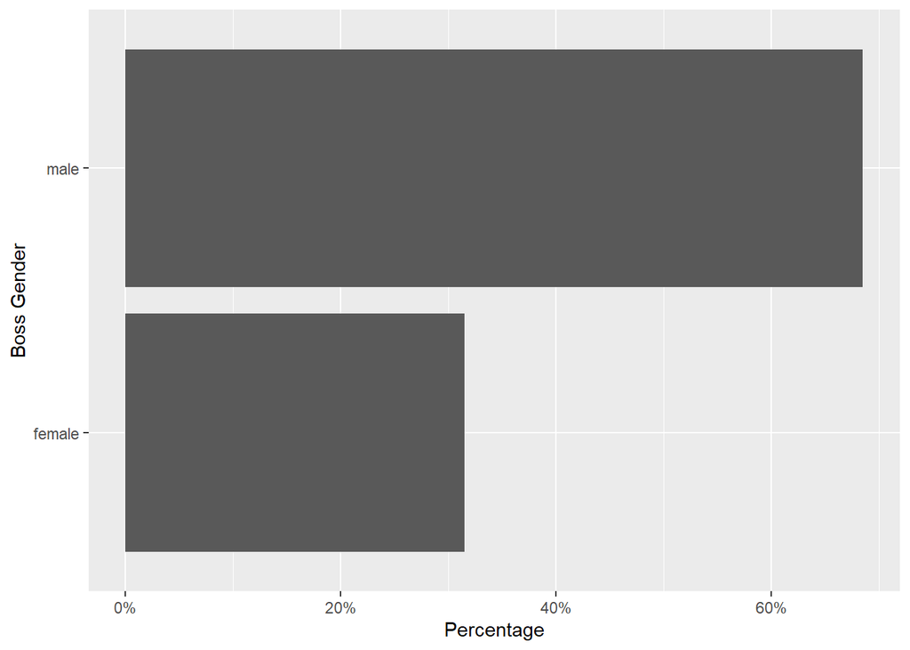

```r
#### Q3.2
### plot single categorical variable
## choose data and mapping
ggplot(data = div_work_data, mapping = aes(y = BossGender)) +
  ## choose geometry with proportion calculation
  geom_bar(aes(x = ..prop.., group = 1)) +
  ## label axes
  labs(y = "Boss Gender", x = "Percentage") +
  ## change format of x-axis
  scale_x_continuous(labels = scales::percent_format())
```

```r
#### Q3.3
### cross-tabulate multiple categorical variables
## specify formula input with variables from data
xtabs(~ BossGender + Gender, data = div_work_data)
```

```
##           Gender
## BossGender Female Male
##     female    300  169
##     male      446  576
```

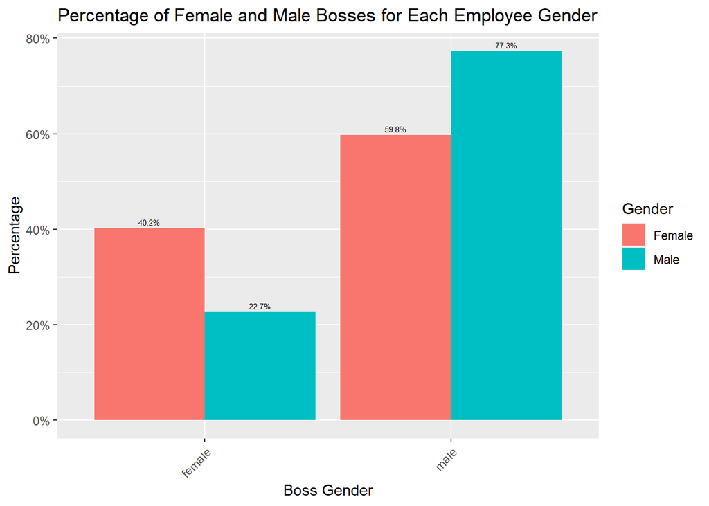

```r
#### Q3.4
### plot multiple categorical variables;
## choose data
ggplot(data = div_work_data %>%
         # filter for only non-missing values
         filter(!is.na(Gender)),
       ## specify mapping
       mapping = aes(x = BossGender,
                     group = Gender,
                     fill = Gender)) +
  ## choose geometry with proportion calculation
  geom_bar(aes(y = ..prop..),
           position = "dodge") +
  ## label mappings
  labs(x = "Boss Gender", y = "Percentage", fill = "Gender") +
  ## change format of y-axis
  scale_y_continuous(labels = scales::percent_format()) +
  ## add text above bars
            # stat for geometry
  geom_text(stat = "count",
                # location of label
            aes(y = ..prop..,
                # label and number of digits
                label = scales::percent(..prop.., accuracy = 0.1)),
            # justify vertically above bar
            vjust = -0.5,
            # position label above each bar
            position = position_dodge(0.9), size = 2) +
  ## change angle of x-axis labels
  theme(axis.text.x = element_text(angle = 45, hjust = 1)) +
  ## add descriptive title
  ggtitle("Percentage of Female and Male Bosses for Each Employee Gender")
```

## Task 4: Summarize and Visualize Continuous and Categorical Variables

For this task, you will examine the **BossGender**, **Gender**, and **Tenure** variables in the **div_work_data** data object.

Copy the relevant code from the analytical lecture to mutate **Tenure** into a new ordered factor variable. You will need to exchange **JobGrade** for **BossGender** in the copied code. Save the result in an object named **ten_prop** just like we did in the analytical lecture. In this code, you compute the count of employees with a particular gender (i.e., male or female), a particular boss gender (i.e., male or female), and a particular range of tenure (i.e., 0-5, 6-10, 11-20, 21+). Once you create **ten_prop**, highlight it and execute to print the result.

**Question 4.1**: How many male employees with 11-20 years of tenure have a female boss? What proportion of female employees with 6-10 years of tenure have a male boss?

**Response 4.1**: *Number of male employees that fit the criteria: 26. Proportion of female employees that fit the criteria: 0.664*.

Using **ten_prop**, create a **ggplot** of **tenure_group**, **Gender**, and **BossGender**. Start by copy the relevant code from the analytical lecture. Name the plot **emp_gen_ten_boss_gen_plot**. Exchange **JobGrade** for **BossGender** in the **group** and **color** aesthetics. Change the title to: *Boss Gender Proportion for Each Employee Gender and Range of Tenure*. Print the plot once created. Save the plot to your *plots* folder in your project directory using **ggsave**. Name the plot: *emp_gen_ten_boss_gen.png*.

**Question 4.2**: Approximately, what percentage of female employees with 21+ years of tenure have a male boss? Approximately, what percentage of male employees with 6-10 years of tenure have a female boss?

**Response 4.2**: *Approx. 63%. Approx. 27%*.

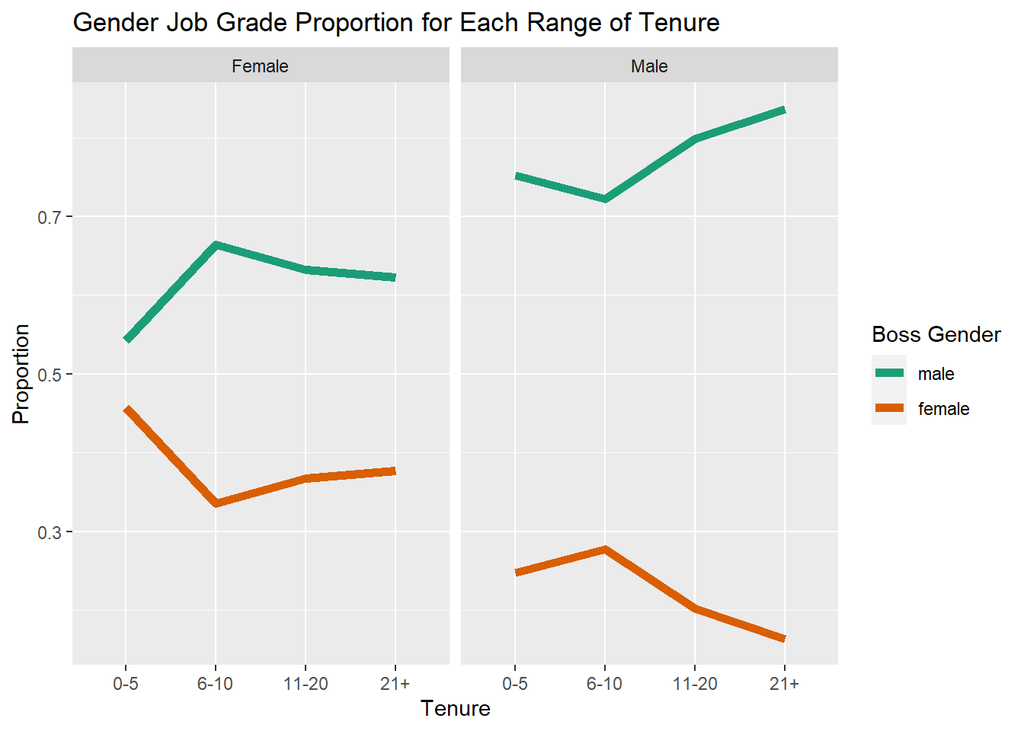

```r
#### Q4.1
### compute Tenure proportion as a function of BossGender
## compute data
ten_prop <- div_work_data %>%
  ## create grouped Tenure variable
  mutate(tenure_group = factor(case_when(
    Tenure <= 5 ~ "0-5",
    Tenure > 5 & Tenure <= 10 ~ "6-10",
    Tenure > 10 & Tenure <= 20 ~ "11-20",
    Tenure >= 21 ~ "21+"
  ), ordered = TRUE)) %>%
  ## reorder factor
  mutate(tenure_group = fct_relevel(tenure_group,
                                    "6-10", after = 1)) %>%
  ## filter for complete values of Gender
  filter(!is.na(Gender)) %>%
  ## count Tenure and BossGender
  count(tenure_group, BossGender, Gender) %>%
  ## group by tenure_group and Gender
  group_by(tenure_group, Gender) %>%
  ## compute proportion
  mutate(prop = n / sum(n)) %>%
  ## ungroup
  ungroup()

#### Q4.2
### scatterplot of two continuous variables
## save plot; choose data
emp_gen_ten_boss_gen_plot <- ggplot(ten_prop,
        # mapping x, y, and group
        aes(x = tenure_group, y = prop, group = BossGender,
        # reorder factor
        color = fct_reorder2(BossGender, tenure_group, prop))) +
  ## point geometry
  geom_line(size = 2) +
  ## facet wrap Gender
  facet_wrap(vars(Gender), nrow = 1) +
  ## labels
  labs(x = "Tenure", y = "Proportion", color = "Boss Gender") +
  ## change colors
  scale_color_brewer(palette = "Dark2") +
  ## title
  ggtitle("Gender Job Grade Proportion for Each Range of Tenure")

## print plot
emp_gen_ten_boss_gen_plot
```

```r
### Save plots to folder in project directory
## Save a single plot to a file
ggsave(here("plots", "emp_gen_ten_boss_gen.png"), plot = emp_gen_ten_boss_gen_plot,
       units = "in", width = 9, height = 5)
```